# A quick introduction to mdendro

Alberto Fernández, Sergio Gómez

v2.2 (2023-12-31)

## Description

R package [**mdendro**](https://github.com/sergio-gomez/mdendro) enables the calculation of **agglomerative hierarchical clustering** (AHC), extending the standard functionalities in several ways:

- Native handling of both **similarity** and **dissimilarity** (distances) matrices.
- Calculation of pair-group dendrograms and variable-group **multidendrograms** [1].
- Implementation of the most common AHC methods in both **weighted** and **unweighted** forms: single linkage, complete linkage, average linkage (UPGMA and WPGMA), centroid (UPGMC and WPGMC), and Ward.
- Implementation of two additional parametric families of methods: **versatile linkage** [2], and **beta flexible**. Versatile linkage leads naturally to the definition of two additional methods: *harmonic linkage*, and *geometric linkage*.
- Calculation of the **cophenetic** (or **ultrametric**) matrix.
- Calculation of five **descriptors** of the final dendrogram: *cophenetic correlation coefficient*, *space distortion ratio*, *agglomerative coefficient*, *chaining coefficient*, and *tree balance*.
- Plots of the descriptors for the parametric methods.

All this functionality is obtained with functions `linkage`, `descval` and `descplot`. Function `linkage` may be considered as a replacement for functions `hclust` (in package [stats](https://stat.ethz.ch/R-manual/R-devel/library/stats/html/00Index.html)) and `agnes` (in package [cluster](https://stat.ethz.ch/R-manual/R-devel/library/cluster/html/00Index.html)). To enhance usability and interoperability, the `linkage` class includes several methods for plotting, summarizing information, and class conversion.

## Installation

There exist two main ways to install [**mdendro**](https://github.com/sergio-gomez/mdendro):

- Installation from CRAN (recommended method):

  ```r
  install.packages("mdendro")
  ```

  [RStudio](https://posit.co/products/open-source/rstudio/) has a menu entry (Tools $\rightarrow$ Install Packages) for this job.
- Installation from GitHub (you may need to install first devtools):

  ```r
  install.packages("devtools")
  library(devtools)
  install_github("sergio-gomez/mdendro")
  ```

  Since [**mdendro**](https://github.com/sergio-gomez/mdendro) includes C++ code, you may need to install first [Rtools](https://cran.r-project.org/bin/windows/Rtools/) in Windows, or [Xcode](https://developer.apple.com/xcode/) in MacOS.

## Tutorial

### Basics

Let us start by using the `linkage` function to calculate the complete linkage AHC of the `UScitiesD` dataset, a matrix of distances between a few US cities:

```r
library(mdendro)
lnk <- linkage(UScitiesD, method = "complete")
```

Now we can plot the resulting dendrogram:

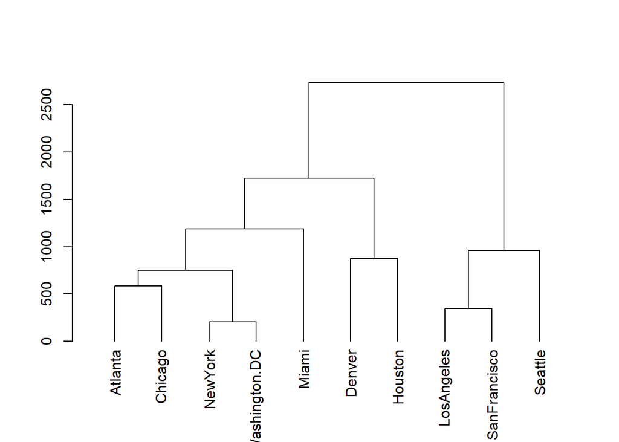

```r
plot(lnk)
```

The summary of this dendrogram is:

```r
summary(lnk)
```

```
## Call:
## linkage(prox = UScitiesD,
##         type.prox = "distance",
##         digits = 0,
##         method = "complete",
##         group = "variable")
##
## Number of objects: 10
##
## Binary dendrogram: TRUE
##
## Descriptive measures:
##       cor       sdr        ac        cc        tb
## 0.8077859 1.0000000 0.7738478 0.3055556 0.9316262
```

In particular, you can recognize the calculated descriptors:

- `cor`: cophenetic correlation coefficient
- `sdr`: space distortion ratio
- `ac`: agglomerative coefficient
- `cc`: chaining coefficient
- `tb`: tree balance

It is possible to work with similarity data without having to convert them to distances, provided they are in range [0.0, 1.0]. A typical example would be a matrix of non-negative correlations:

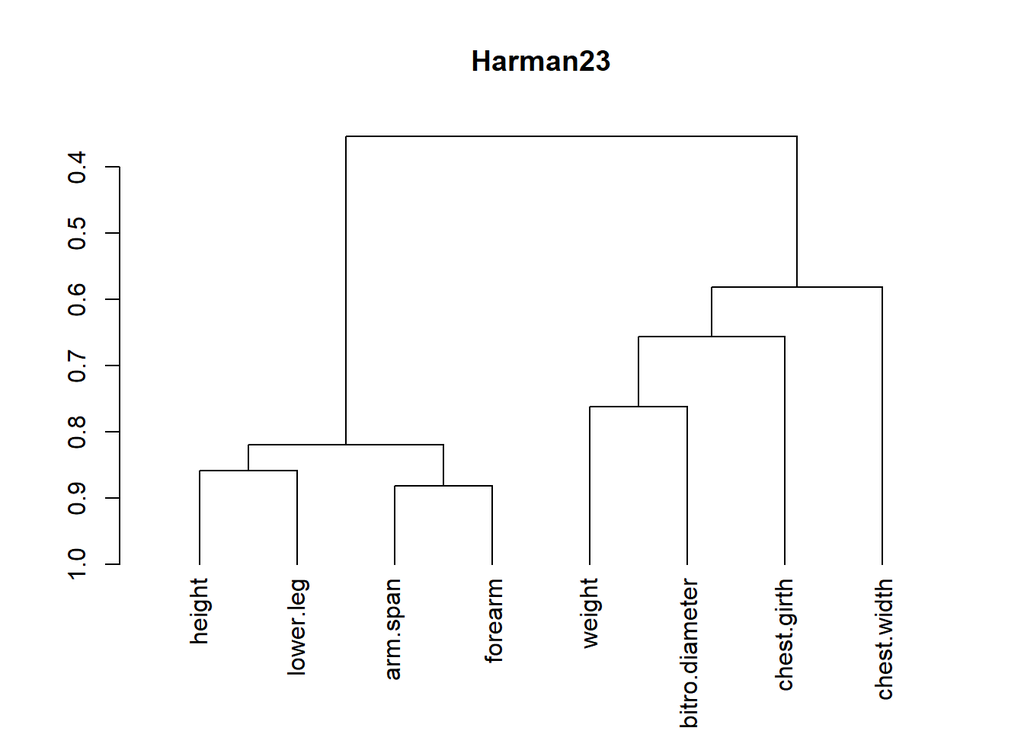

```r
sim <- as.dist(Harman23.cor$cov)
lnk <- linkage(sim, type.prox = "sim")
plot(lnk, main = "Harman23")
```

There is also the option to choose between unweighted (default) and weighted methods:

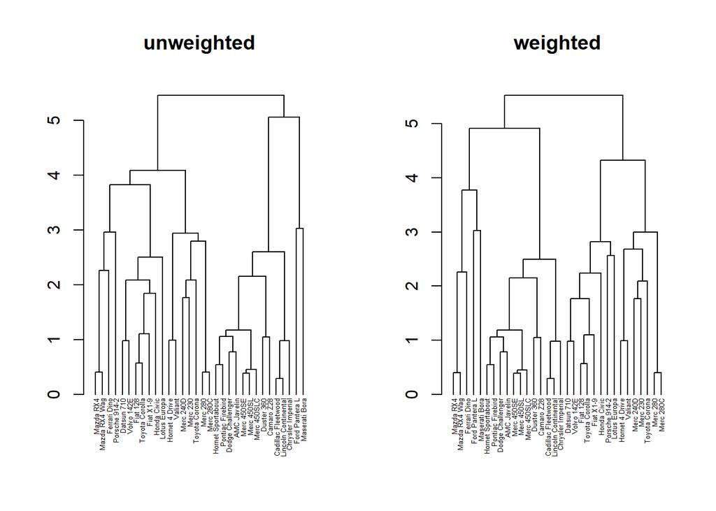

```r
par(mfrow = c(1, 2))
cars <- round(dist(scale(mtcars)), digits = 3)
nodePar <- list(cex = 0, lab.cex = 0.4)

lnk1 <- linkage(cars, method = "arithmetic")
plot(lnk1, main = "unweighted", nodePar = nodePar)

lnk2 <- linkage(cars, method = "arithmetic", weighted = TRUE)
plot(lnk2, main = "weighted", nodePar = nodePar)
```

When there are tied minimum distances in the agglomeration process, you may ignore them and proceed choosing a random pair (pair-group methods) or agglomerate them all at once (variable-group multidendrograms). With `linkage` you can use both approaches, being multidendrograms the default one:

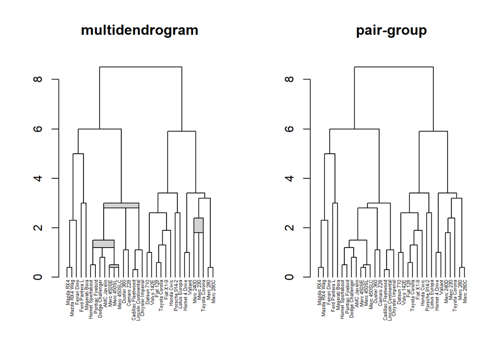

```r
par(mfrow = c(1, 2))
cars <- round(dist(scale(mtcars)), digits = 1)
nodePar <- list(cex = 0, lab.cex = 0.4)

lnk1 <- linkage(cars, method = "complete")
plot(lnk1, main = "multidendrogram", nodePar = nodePar)

lnk2 <- linkage(cars, method = "complete", group = "pair")
plot(lnk2, main = "pair-group", nodePar = nodePar)
```

While multidendrograms are unique, you may obtain structurally different pair-group dendrograms by just reordering the data. As a consequence, the descriptors are invariant to permutations for multidendrograms, but not for pair-group dendrograms:

```r
cars <- round(dist(scale(mtcars)), digits = 1)
lnk1 <- linkage(cars, method = "complete")
lnk2 <- linkage(cars, method = "complete", group = "pair")

# apply random permutation to data
set.seed(666)
ord <- sample(attr(cars, "Size"))
cars_p <- as.dist(as.matrix(cars)[ord, ord])
lnk1p <- linkage(cars_p, method = "complete")
lnk2p <- linkage(cars_p, method = "complete", group = "pair")

# compare original and permuted cophenetic correlation
c(lnk1$cor, lnk1p$cor)
## [1] 0.7782257 0.7782257
c(lnk2$cor, lnk2p$cor)
## [1] 0.7780010 0.7780994

# compare original and permuted tree balance
c(lnk1$tb, lnk1p$tb)
## [1] 0.9564568 0.9564568
c(lnk2$tb, lnk2p$tb)
## [1] 0.9472909 0.9424148
```

In multidendrograms, the ranges (rectangles) show the heterogeneity between distances within the group, but they are optional in the plots:

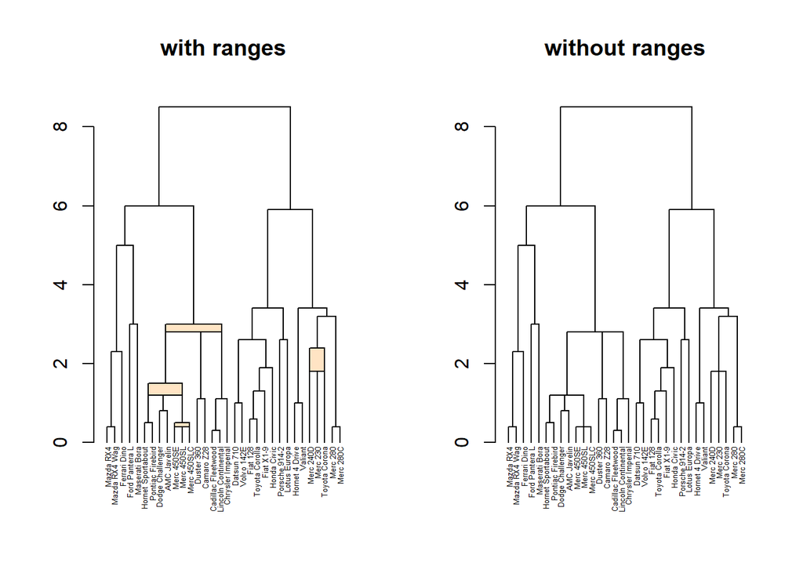

```r
par(mfrow = c(1, 2))
cars <- round(dist(scale(mtcars)), digits = 1)
nodePar <- list(cex = 0, lab.cex = 0.4)
lnk <- linkage(cars, method = "complete")
plot(lnk, col.rng = "bisque", main = "with ranges", nodePar = nodePar)
plot(lnk, col.rng = NULL, main = "without ranges", nodePar = nodePar)
```

Plots including ranges are only available if you directly use the `plot.linkage` function from [**mdendro**](https://github.com/sergio-gomez/mdendro). Anyway, you may still take advantage of other dendrogram plotting packages, such as dendextend and ape:

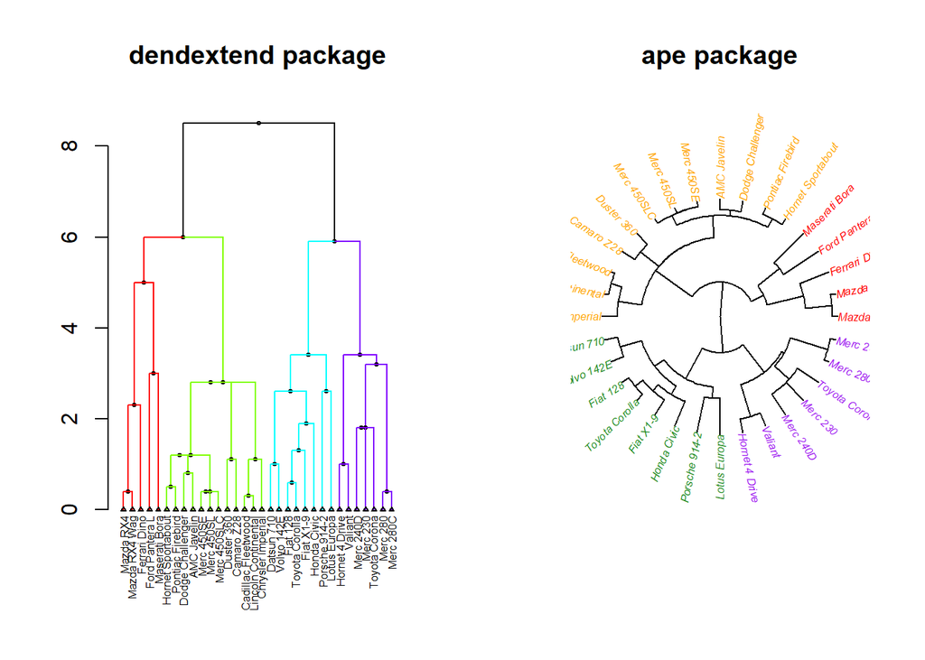

```r
par(mfrow = c(1, 2))
cars <- round(dist(scale(mtcars)), digits = 1)
lnk <- linkage(cars, method = "complete")

lnk.dend <- as.dendrogram(lnk)
plot(dendextend::set(lnk.dend, "branches_k_color", k = 4),
     main = "dendextend package",
     nodePar = list(cex = 0.4, lab.cex = 0.5))
lnk.hcl <- as.hclust(lnk)
pal4 <- c("red", "forestgreen", "purple", "orange")
clu4 <- cutree(lnk.hcl, 4)
plot(ape::as.phylo(lnk.hcl),
     type = "fan",
     main = "ape package",
     tip.color = pal4[clu4],
     cex = 0.5)
```

In addition, you can also use the `linkage` function to plot heatmaps containing multidendrograms:

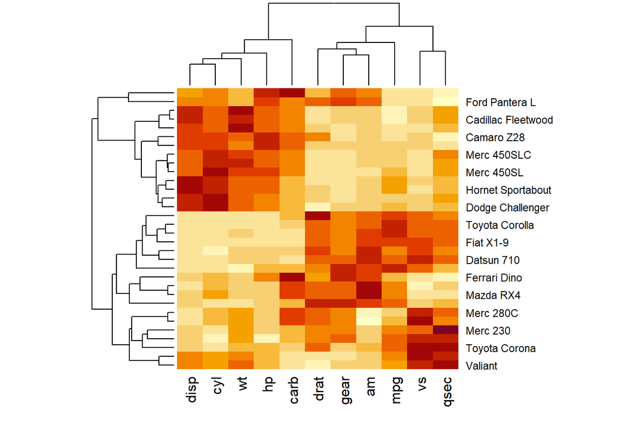

```r
heatmap(scale(mtcars), hclustfun = linkage)
```

### Linkage methods

The list of available AHC linkage methods is the following: *single*, *complete*, *arithmetic*, *geometric*, *harmonic*, *versatile*, *ward*, *centroid* and *flexible*. Their equivalences with the methods in other packages can be found below. The default method is *arithmetic*, which is also commonly known as *average linkage* or *UPGMA*.

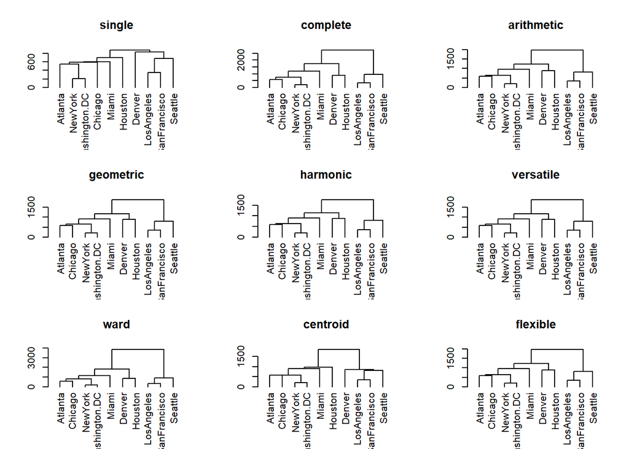

```r
par(mfrow = c(3, 3))
methods <- c("single", "complete", "arithmetic",
             "geometric", "harmonic", "versatile",
             "ward", "centroid", "flexible")

for (m in methods) {
  lnk <- linkage(UScitiesD, method = m)
  plot(lnk, cex = 0.6, main = m)
}
```

Two of the methods, *versatile* and *flexible*, depend on a parameter that takes values in (-Inf, +Inf) for *versatile*, and in [-1.0, +1.0] for *flexible*. Here come some examples:

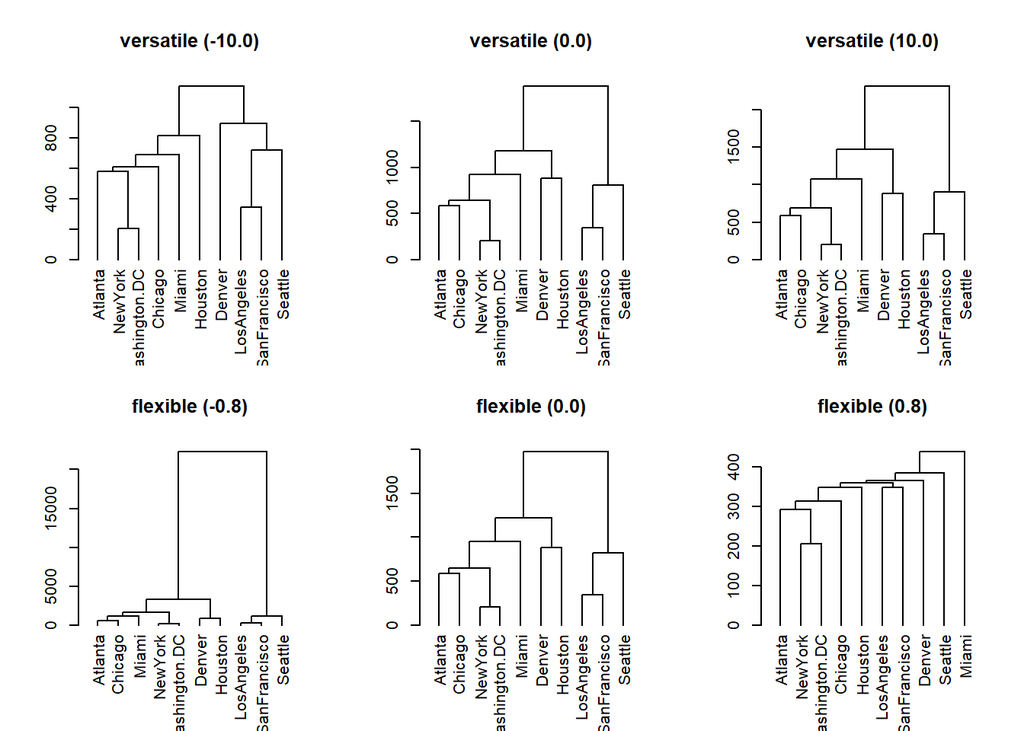

```r
par(mfrow = c(2, 3))

vals <- c(-10.0, 0.0, 10.0)
for (v in vals) {
  lnk <- linkage(UScitiesD, method = "versatile", par.method = v)
  plot(lnk, cex = 0.6, main = sprintf("versatile (%.1f)", v))
}

vals <- c(-0.8, 0.0, 0.8)
for (v in vals) {
  lnk <- linkage(UScitiesD, method = "flexible", par.method = v)
  plot(lnk, cex = 0.6, main = sprintf("flexible (%.1f)", v))
}
```

It is interesting to know how the descriptors depend on those parameters. Package [**mdendro**](https://github.com/sergio-gomez/mdendro) provides two specific functions for this task, namely `descval` and `descplot`, which return just the numerical values or also the corresponding plot, respectively. For example, using *versatile* linkage:

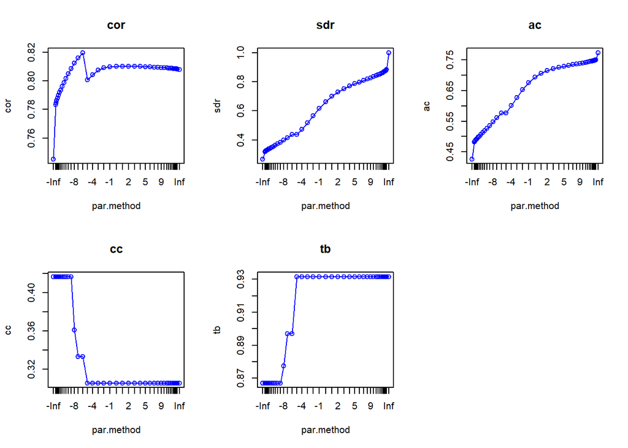

```r
par(mfrow = c(2, 3))
measures <- c("cor", "sdr", "ac", "cc", "tb")
vals <- c(-Inf, (-20:+20), +Inf)
for (m in measures)
  descplot(UScitiesD, method = "versatile",
           measure = m, par.method = vals,
           type = "o",  main = m, col = "blue")
```

Similarly for the *flexible* method:

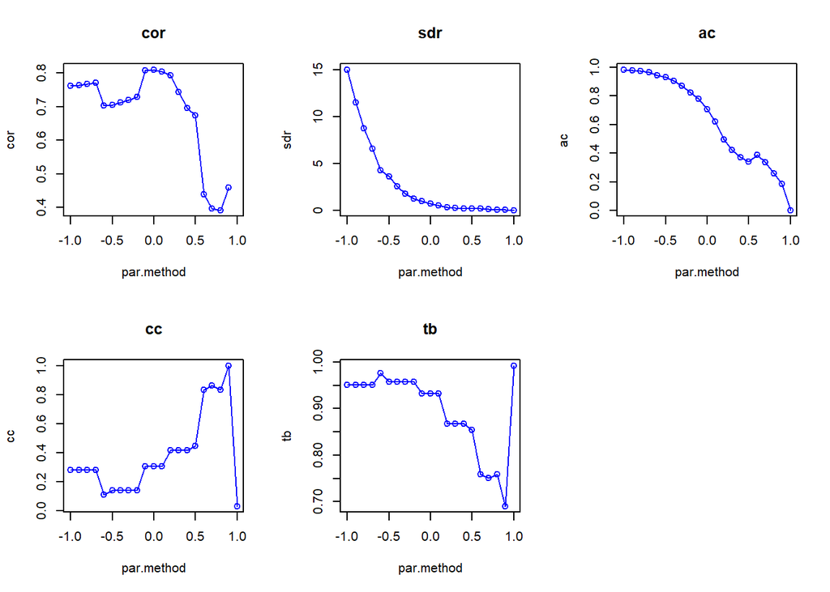

```r
par(mfrow = c(2, 3))
measures <- c("cor", "sdr", "ac", "cc", "tb")
vals <- seq(from = -1, to = +1, by = 0.1)
for (m in measures)
  descplot(UScitiesD, method = "flexible",
           measure = m, par.method = vals,
           type = "o",  main = m, col = "blue")
```

### Comparison with other packages

For comparison, the same AHC can be found using functions `hclust` and `agnes`, where the default plots just show some differences in aesthetics:

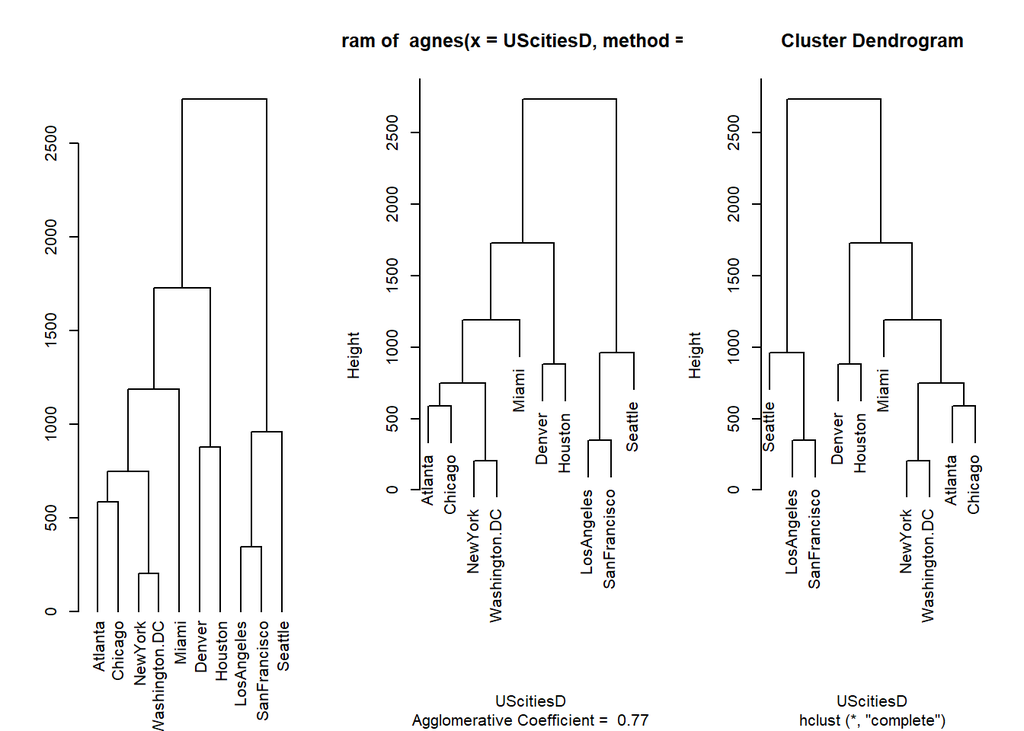

```r
library(mdendro)
lnk <- linkage(UScitiesD, method = "complete")

library(cluster)
agn <- agnes(UScitiesD, method = "complete")

# library(stats)   # unneeded, stats included by default
hcl <- hclust(UScitiesD, method = "complete")

par(mfrow = c(1, 3))
plot(lnk)
plot(agn, which.plots = 2)
plot(hcl)
```

Converting to class dendrogram, we can see all three are structurally equivalent:

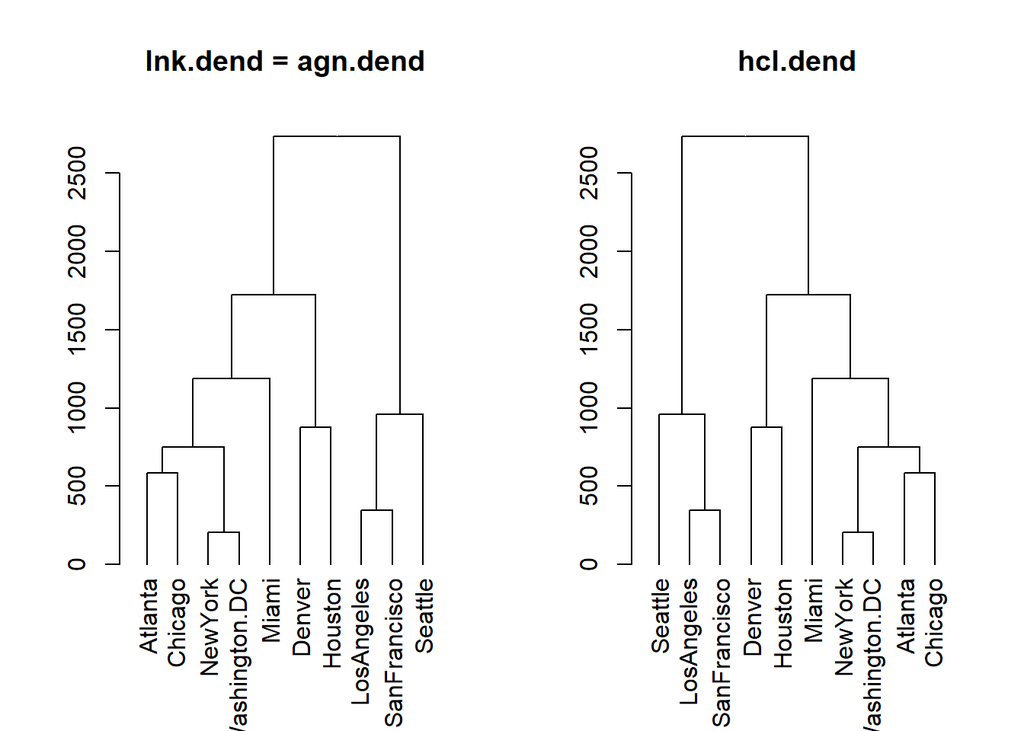

```r
lnk.dend <- as.dendrogram(lnk)
agn.dend <- as.dendrogram(agn)
hcl.dend <- as.dendrogram(hcl)
identical(lnk.dend, agn.dend)
## [1] TRUE

par(mfrow = c(1, 2))
plot(lnk.dend, main = "lnk.dend = agn.dend", cex = 0.7)
plot(hcl.dend, main = "hcl.dend", cex = 0.7)
```

The cophenetic (ultrametric) matrix is readily available as component `coph` of the returned `linkage` object, and coincides with those obtained using the other functions:

```r
hcl.coph <- cophenetic(hcl)
agn.coph <- cophenetic(agn)

all(lnk$coph == hcl.coph)
## [1] TRUE
all(lnk$coph == agn.coph)
## [1] TRUE
```

The coincidence also applies to the cophenetic correlation coefficient and agglomerative coefficient, with the advantage that `linkage` has them all already calculated:

```r
hcl.cor <- cor(UScitiesD, hcl.coph)
all.equal(lnk$cor, hcl.cor)
## [1] TRUE

all.equal(lnk$ac, agn$ac)
## [1] TRUE
```

The computational efficiency of the three functions is compared next, both in linear scale (left) and in log-log scale (right). It can be observed that the time cost of functions `linkage` and `hclust` is quadratic, whereas that of function `agnes` is cubic:

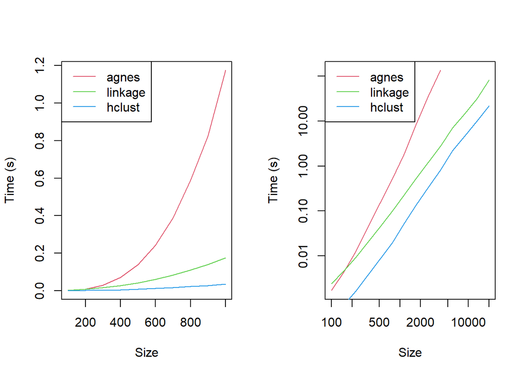

## Rationale

Package [**mdendro**](https://github.com/sergio-gomez/mdendro) was initially designed to make publicly available implementations of our work on agglomerative hierarchical clustering (AHC) [1, 2], trying to reach a wide community through the use of the R language. We already have two implementations, a Java application called [MultiDendrograms](https://webs-deim.urv.cat/~sergio.gomez/multidendrograms.php), and a `Hierarchical_Clustering` tool within our [Radatools](https://webs-deim.urv.cat/~sergio.gomez/radatools.php) set of programs for the analysis of complex networks, whose Ada source code can be found in [Radalib](https://webs-deim.urv.cat/~sergio.gomez/radalib.php).

Apart from providing access to our algorithms, we also wanted to simplify how to use them, and improve the performance of their implementations. All this was accomplished by using state-of-the-art methods based on neighbor chains, implementing the base code in C++, and adding functionality to make the new package very similar and compatible with the main ones currently in use, namely the functions `hclust` in package [stats](https://stat.ethz.ch/R-manual/R-devel/library/stats/html/00Index.html), and `agnes` in package [cluster](https://stat.ethz.ch/R-manual/R-devel/library/cluster/html/00Index.html). The result is a package [**mdendro**](https://github.com/sergio-gomez/mdendro) that includes and largely extends the functionality of these reference functions, thus with the option of being a replacement for them.

The main novelties in [**mdendro**](https://github.com/sergio-gomez/mdendro), which are not available in other packages, are the following:

- Calculation of variable-group **multidendrograms**, which solve the non-unicity problem of AHC when there are tied distances [1].
- Native handling of **similarity** matrices.
- Explicit separation of **weighted** and **unweighted** methods of AHC.
- Implementation of a new parametric family of methods: **versatile linkage** [2].
- Automatic calculation of the **cophenetic** (or **ultrametric**) matrix.
- Automatic calculation of five **descriptors** of the final dendrogram: cophenetic correlation coefficient, space distortion ratio, agglomerative coefficient, chaining coefficient, and tree balance.
- Plots of the descriptors for the parametric methods.

### Multidendrograms

#### Description

**Multidendrograms** are the hierarchical structures that are obtained after applying the variable-group AHC algorithms introduced in [1]. They solve the *non-uniqueness problem* found in the standard pair-group algorithms and implementations [3]. This problem arises when two or more minimum distances between different clusters are equal during the amalgamation process. The standard approach consists in choosing a pair, breaking the ties between distances, and proceeding in the same way until the final hierarchical classification is obtained. However, different clusterings are possible depending on the criterion used to break the ties (usually a pair is just chosen at random), and the user is unaware of this problem.

The variable-group algorithms group more than two clusters at the same time when ties occur, given rise to a graphical representation called multidendrogram. Their main properties are:

- When there are no ties, the variable-group algorithms give the same results as the pair-group ones.
- They always give a uniquely-determined solution.
- In the multidendrogram representation for the results, one can explicitly observe the occurrence of ties during the agglomerative process. Furthermore, the height of any fusion interval (the ranges or bands) indicates the degree of heterogeneity inside the corresponding cluster.

Both `hclust` and `agnes` ignore this non-uniqueness problem, thus the need for [**mdendro**](https://github.com/sergio-gomez/mdendro).

#### Example

Let us consider the genetic profiles of 51 grapevine cultivars at 6 microsatellite loci [4]. The distance between two cultivars is defined as one minus the fraction of shared alleles, that we use to calculate a distance matrix `d`. The main characteristic of this kind of data is that the number of different distances is very small:

```r
length(unique(d))
## [1] 11
```

As a consequence, it becomes very easy to find tied distances during the agglomeration process. The corresponding unique *multidendrogram* is the following:

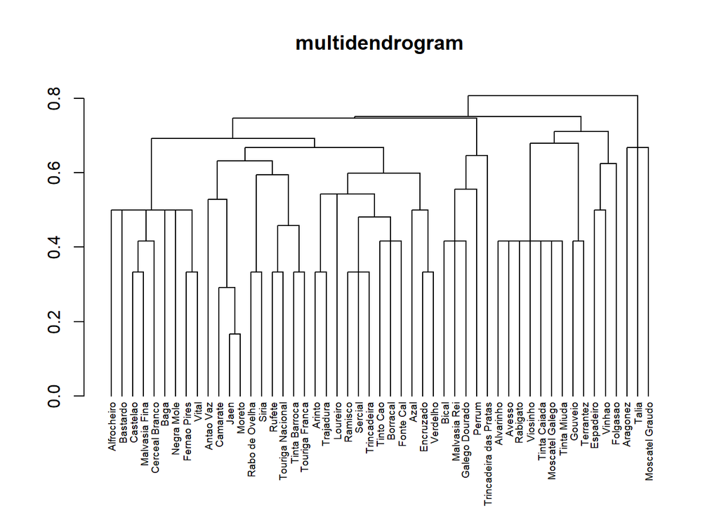

```r
lnk <- linkage(d, method = "arithmetic", digits = 3)
nodePar <- list(cex = 0, lab.cex = 0.6)
plot(lnk, col.rng = NULL, nodePar = nodePar, main = "multidendrogram")
```

The reach of the non-uniqueness problem for this example is the existence of

- 760,590,880 structurally different binary dendrograms

This number corresponds to arithmetic linkage and a resolution of 3 decimal digits, and has been computed using the `Hierarchical_Clustering` tool in [Radatools](https://webs-deim.urv.cat/~sergio.gomez/radatools.php). We can check this fact by just calculating the binary dendrogram for random permutations of the data, and plotting the broad range of values of their cophenetic correlations, which clearly indicate the existence of many structurally different dendrograms:

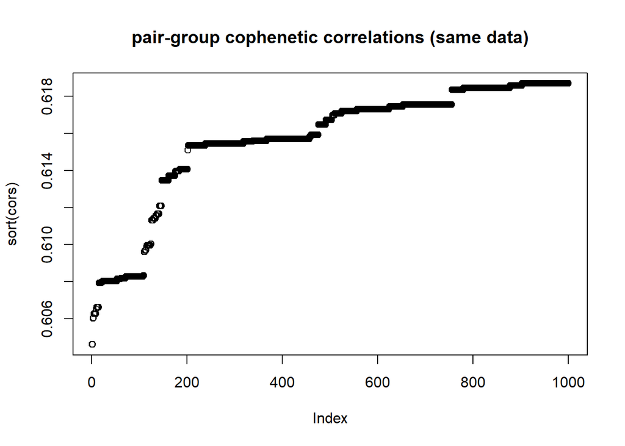

```r
nreps <- 1000
cors <- vector(length = nreps)
lnks <- list()
for (r in 1:nreps) {
    ord <- sample(attr(d, "Size"))
    d2 <- as.dist(as.matrix(d)[ord, ord])
    lnks[[r]] <- linkage(d2, group = "pair", digits = 3)
    cors[r] <- lnks[[r]]$cor
}
plot(sort(cors), main = "pair-group cophenetic correlations (same data)")
```

For example, the first two pair-group dendrograms calculated above are structurally different:

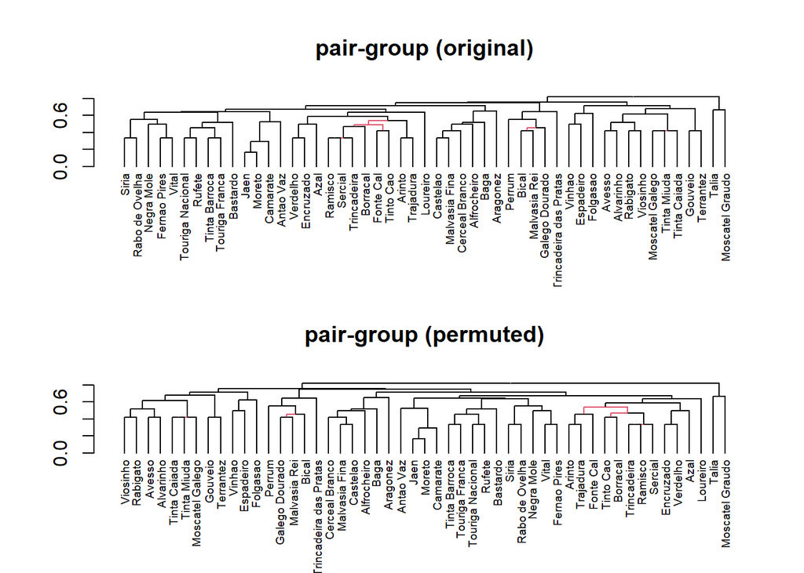

```r
dend1 <- as.dendrogram(lnks[[1]])
dend2 <- as.dendrogram(lnks[[2]])
diff_12 <- dendextend::highlight_distinct_edges(dend1, dend2)
diff_21 <- dendextend::highlight_distinct_edges(dend2, dend1)

par(mfrow = c(2, 1))
nodePar <- list(cex = 0, lab.cex = 0.6)
plot(diff_12, nodePar = nodePar, main = "pair-group (original)")
plot(diff_21, nodePar = nodePar, main = "pair-group (permuted)")
```

The identification of ties requires the selection of the number of significant digits in our data. For example, if the original distances are experimentally obtained with a resolution of three decimal digits, two distances that differ in the sixth decimal digit should be considered as equal. If this is not taken into account, ties may be broken just by the numerical imprecision inherent to computer representations of real numbers. In the `linkage` function, you can control this level of resolution by adjusting its `digits` argument.

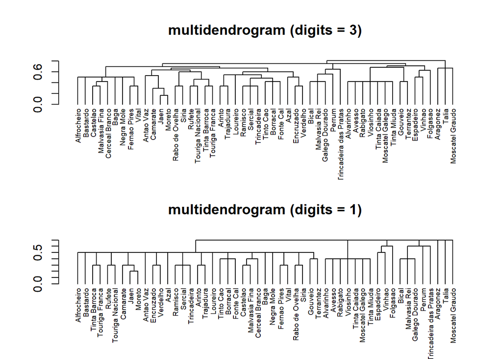

```r
lnk3 <- linkage(d, method = "arithmetic", digits = 3)
lnk1 <- linkage(d, method = "arithmetic", digits = 1)

par(mfrow = c(2, 1))
nodePar <- list(cex = 0, lab.cex = 0.6)
plot(lnk3, col.rng = NULL, nodePar = nodePar,
     main = "multidendrogram (digits = 3)")
plot(lnk1, col.rng = NULL, nodePar = nodePar,
     main = "multidendrogram (digits = 1)")
```

### Versatile linkage

Package [**mdendro**](https://github.com/sergio-gomez/mdendro) also introduces a new family of *space-conserving* hierarchical clustering methods called **versatile linkage** [2]. It is based on the use of [*generalized means*](https://en.wikipedia.org/wiki/Generalized_mean), and includes single linkage, complete linkage and arithmetic linkage (a.k.a. average linkage or UPGMA/WPGMA) as particular cases. Additionally, versatile linkage naturally leads to the definition of two new methods, geometric linkage and harmonic linkage (hence the convenience to rename average linkage as arithmetic linkage, to emphasize the existence of different types of averages).

In function `linkage`, the parameter of versatile linkage is introduced using the `par.method` argument. It can take any real value, and the correspondence between versatile linkage and the above mentioned methods is the following:

| linkage | versatile linkage (`par.method`) |
| --- | --- |
| complete | Inf |
| arithmetic | 1 |
| geometric | 0 |
| harmonic | -1 |
| single | -Inf |

Let us show a small example in which we plot the different (multi)dendrograms as we increase the versatile linkage parameter, indicating the corresponding *named* methods:

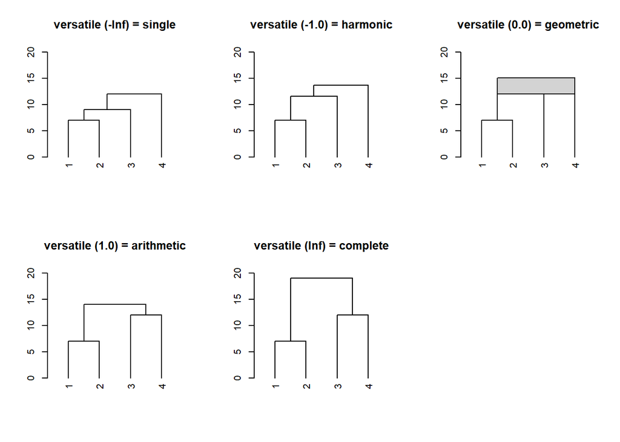

```r
d = as.dist(matrix(c( 0,  7, 16, 12,
                      7,  0,  9, 19,
                     16,  9,  0, 12,
                     12, 19, 12, 0), nrow = 4))

par(mfrow = c(2, 3))

vals <- c(-Inf, -1, 0, 1, Inf)
names <- c("single", "harmonic", "geometric", "arithmetic", "complete")
titles <- sprintf("versatile (%.1f) = %s", vals, names)

for (i in 1:length(vals)) {
  lnk <- linkage(d, method = "versatile", par.method = vals[i], digits = 2)
  plot(lnk, ylim = c(0, 20), cex = 0.6, main = titles[i])
}
```

## Reference manual

### Usage

```r
linkage(prox, type.prox = "distance", digits = NULL,
        method = "arithmetic", par.method = 0, weighted = FALSE,
        group = "variable")

descval(prox, type.prox = "distance", digits = NULL,
        method = "versatile", par.method = c(-1,0,+1), weighted = FALSE,
        group = "variable", measure = "cor")

descplot(prox, ..., type.prox = "distance", digits = NULL,
         method = "versatile", par.method = c(-1, 0, +1), weighted = FALSE,
         group = "variable", measure = "cor", slope = 10)
```

Arguments:

| `prox` | A structure of class `dist` containing non-negative proximity data (distances or similarities). All the linkage methods are meant to be used with non-squared proximity data as input. |
| --- | --- |
| `type.prox` | A character string to indicate whether the proximity data represent `"distance"` (default) or `"similarity"` between objects. Methods `"ward"` and `"centroid"` cannot be used with similarity data as i… |
| `digits` | An integer value specifying the precision, i.e., the number of significant decimal digits to be used for the comparisons between proximity data. This is an important parameter, since equal proximity d… |
| `method` | A character string specifying the linkage method to be used. For `linkage()`, this should be one of: `"single"`, `"complete"`, `"arithmetic"`, `"geometric"`, `"harmonic"`, `"versatile"`, `"ward"`, `"c… |
| `par.method` | A real value, in the case of `linkage()`, or a vector of real values, in the case of `descval()` and `descplot()`, required as parameter for the methods `"versatile"` and `"flexible"`. The range of po… |
| `weighted` | A logical value to choose between the weighted and the unweighted (default) versions of some linkage methods. Weighted linkage gives merging branches in a dendrogram equal weight regardless of the num… |
| `group` | A character string to choose a grouping criterion between the `"variable"`-group approach (default) that returns a multidendrogram, i.e., a multifurcated dendrogram (m-ary tree), and the `"pair"`-grou… |
| `measure` | A character string specifying the descriptive measure to be plotted. This should be one of: `"cor"`, for cophenetic correlation coefficient; `"sdr"`, for space distortion ratio; `"ac"`, for agglomerat… |
| `slope` | A real value representing the slope of a sigmoid function to map the `"versatile"` linkage unbounded interval (-Inf, +Inf) onto the bounded interval (-1, +1). It can be used to improve the distributio… |
| `...` | Graphical parameters may also be supplied (see `par`) and are passed to `plot.default`. |

```r
## S3 method for class 'linkage'
plot(x, type = c("rectangle", "triangle"),
     center = FALSE, edge.root = FALSE,
     nodePar = NULL, edgePar = list(),
     leaflab = c("perpendicular", "textlike", "none"),
     dLeaf = NULL, xlab = "", ylab = "", xaxt = "n", yaxt = "s",
     horiz = FALSE, frame.plot = FALSE, xlim, ylim,
     col.rng = "lightgray", ...)
```

Arguments:

| `x` | An object of class `linkage`, typically created by `linkage()`. |
| --- | --- |
| `type` | Type of plot |
| `center` | Logical; if `TRUE`, nodes are plotted centered with respect to the leaves in the branch. Otherwise (default), plot them in the middle of all direct child nodes. |
| `edge.root` | Logical; if `TRUE`, draw an edge to the root node. |
| `nodePar` | A `list` of plotting parameters to use for the nodes (see `points`), or `NULL` by default which does not draw symbols at the nodes. The list may contain components named `pch`, `cex`, `col`, `xpd`, an… |
| `edgePar` | A `list` of plotting parameters to use for the edge `segments`. The list may contain components named `co`l, `lty` and `lwd`. As with `nodePar`, each can have length two for differentiating leaves and… |
| `leaflab` | A string specifying how leaves are labeled. The default `"perpendicular"` writes text vertically (by default), `"textlike"` writes text horizontally (in a rectangle), and `"none"` suppresses leaf labe… |
| `dLeaf` | A number specifying the distance in user coordinates between the tip of a leaf and its label. If `NULL` as per default, 3/4 of a letter width or height is used. |
| `xlab`,`ylab` | A label for the axis. |
| `xaxt`,`yaxt` | A character which specifies the axis type. Specifying `"n"` suppresses plotting, while any value other than `"n"` implies plotting. |
| `horiz` | Logical indicating if the dendrogram should be drawn horizontally or not. |
| `frame.plot` | Logical indicating if a box around the plot should be drawn, see `plot.default`. |
| `xlim`,`ylim` | Optional x- and y-limits of the plot, passed to `plot.default`. The defaults for these show the full dendrogram. |
| `col.rng` | Color (`"lightgray"` by default) to be used for plotting range rectangles in case of tied heights. If `NULL`, range rectangles are not plotted. |
| `...` | Graphical parameters (see `par`) may also be supplied and are passed to `plot.default`. |

Based on the plot function for objects of class `dendrogram` (see `plot.dendrogram`), the `plot` function for objects of class `linkage` adds the possibility of visualizing the existence of tied heights in a dendrogram thanks to the `col.rng` parameter.

### Results

An object of class `linkage` that describes the multifurcated dendrogram obtained. The object is a list with the following components:

| `call` | The call that produced the result. |
| --- | --- |
| `digits` | Number of significant decimal digits used as precision. It is given by the user or automatically set to the number of significant decimal digits in the input proximity data. |
| `merger` | A list of vectors of integer that describes the merging of clusters at each step of the clustering. If a number *j* in a vector is negative, then singleton cluster *-j* was merged at this stage. If *j… |
| `height` | A vector with the proximity values between merging clusters (for the particular agglomeration) at the successive stages. |
| `range` | A vector with the range (the maximum minus the minimum) of proximity values between merging clusters. It is equal to 0 for binary clusters. |
| `order` | A vector giving a permutation of the original observations to allow for plotting, in the sense that the branches of a clustering tree will not cross. |
| `coph` | Object of class `dist` containing the cophenetic (or ultrametric) proximity data in the output dendrogram, sorted in the same order as the input proximity data in `prox`. |
| `binary` | A logical value indicating whether the output dendrogram is a binary tree or, on the contrary, it contains an agglomeration of more than two clusters due to the existence of tied proximity data. Its v… |
| `cor` | Cophenetic correlation coefficient [5], defined as the Pearson correlation coefficient between the output cophenetic proximity data and the input proximity data. It is a measure of how faithfully the … |
| `sdr` | Space distortion ratio [2], calculated as the difference between the maximum and minimum cophenetic proximity data, divided by the difference between the maximum and minimum initial proximity data. Sp… |
| `ac` | Agglomerative coefficient [6], a number between 0 and 1 measuring the strength of the clustering structure obtained. |
| `cc` | Chaining coefficient [7], a number between 0 and 1 measuring the tendency for clusters to grow by the addition of clusters much smaller rather than by fusion with other clusters of comparable size. |
| `tb` | Tree balance [2], a number between 0 and 1 measuring the equality in the number of leaves in the branches concerned at each fusion in the hierarchical tree. |

Class `linkage` has methods for the following generic functions: `print`, `summary`, `plot` (see `plot.linkage`), `as.dendrogram`, `as.hclust` and `cophenetic`.

### Supported linkage methods

The difference between the available hierarchical clustering methods rests in the way the proximity between two clusters is defined from the proximity between their constituent objects:

- `"single"`: the proximity between clusters equals the minimum distance or the maximum similarity between objects.
- `"complete"`: the proximity between clusters equals the maximum distance or the minimum similarity between objects.
- `"arithmetic"`: the proximity between clusters equals the arithmetic mean proximity between objects. Also known as average linkage, WPGMA (weighted version) or UPGMA (unweighted version).
- `"geometric"`: the proximity between clusters equals the geometric mean proximity between objects.
- `"harmonic"`: the proximity between clusters equals the harmonic mean proximity between objects.
- `"versatile"`: the proximity between clusters equals the generalized power mean proximity between objects. It depends on the value of par.method, with the following linkage methods as particular cases: `"complete"` (`par.method = +Inf`), `"arithmetic"` (`par.method = +1`), `"geometric"` (`par.method = 0`), `"harmonic"` (`par.method = -1`) and `"single"` (`par.method = -Inf`).
- `"ward"`: the distance between clusters is a weighted squared Euclidean distance between the centroids of each cluster. This method is available only for distance data.
- `"centroid"`: the distance between clusters equals the square of the Euclidean distance between the centroids of each cluster. Also known as WPGMC (weighted version) or UPGMC (unweighted version). This method is available only for distance data. Note that both centroid versions, weighted and unweighted, may yield inversions that make dendrograms difficult to interpret.
- `"flexible"`: the proximity between clusters is a weighted sum of the proximity between clusters in the previous iteration. It depends on the value of `par.method`, in the range [-1, +1], and it is equivalent to `"arithmetic"` linkage when `par.method = 0`.

### Equivalences with other packages

Except for the cases containing tied distances, the following equivalences hold between function `linkage` in package *mdendro*, function `hclust` in package *stats*, and function `agnes` in package *cluster*. Special attention must be paid to the equivalence with methods `"centroid"` and `"median"` of function `hclust`, since these methods require the input distances to be squared before calling `hclust` and, consequently, the square root of its results should be taken afterwards. When relevant, weighted (W) or unweighted (U) versions of the linkage methods and the value for `par.method` are indicated:

| `linkage` | `hclust` | `agnes` |
| --- | --- | --- |
| single | single | single |
| complete | complete | complete |
| arithmetic, U | average | average |
| arithmetic, W | mcquitty | weighted |
| geometric, U/W | — | — |
| harmonic, U/W | — | — |
| versatile, U/W, $p$ | — | — |
| — | ward | — |
| ward | ward.D2 | ward |
| centroid, U | centroid | — |
| centroid, W | median | — |
| flexible, U, $\beta$ | — | gaverage, $\beta$ |
| — | — | gaverage, $\alpha_1$, $\alpha_2$, $\beta$, $\gamma$ |
| flexible, W, $\beta$ | — | flexible, $(1-\beta)/2$ |
| — | — | flexible, $\alpha_1$, $\alpha_2$, $\beta$, $\gamma$ |

## History

#### *mdendro 2.2*

New function `descval`, that can be used instead of `descplot` when the plots are not needed.

#### *mdendro 2.1*

New logical value added to objects of class `linkage`, indicating whether the output dendrogram is a binary tree.

#### *mdendro 2.0*

Fully new implementation from scratch, programmed in C++, using the efficient technique of neighbor chains, including plotting capabilities, and compatible with the main hierarchical clustering and dendrogram packages in R.

#### *mdendro 1.0*

Initial R version based on the [MultiDendrograms](https://webs-deim.urv.cat/~sergio.gomez/multidendrograms.php) Java core for the calculations.

## Authors

- **Alberto Fernández**: Dept. Enginyeria Química, Universitat Rovira i Virgili, Tarragona (Spain). (email) ([ORCID](https://orcid.org/0000-0002-1241-1646)) ([Google Scholar](https://scholar.google.es/citations?user=AbH4r0IAAAAJ)) ([GitHub](https://github.com/albyfs))
- **Sergio Gómez**: Dept. Enginyeria Informàtica i Matemàtiques, Universitat Rovira i Virgili, Tarragona (Spain). ([web](https://webs-deim.urv.cat/~sergio.gomez/)) (email) ([ORCID](https://orcid.org/0000-0003-1820-0062)) ([Google Scholar](https://scholar.google.es/citations?user=ETrjkSIAAAAJ)) ([GitHub](https://github.com/sergio-gomez)) ([Twitter](https://twitter.com/SergioGomezJ))

## Bibliography

1.

A. Fernández, S. Gómez. Solving non-uniqueness in agglomerative hierarchical clustering using multidendrograms. *Journal of Classification* **25**, 43–65 (2008). https:/doi.org/10.1007/s00357-008-9004-x.

2.

A. Fernández, S. Gómez. Versatile linkage: A family of space-conserving strategies for agglomerative hierarchical clustering. *Journal of Classification* **37**, 584–597 (2020). https:/doi.org/10.1007/s00357-019-09339-z.

3.

G. Hart, “[The occurrence of multiple UPGMA phenograms](https://doi.org/10.1007/978-3-642-69024-2_30)” in *Numerical Taxonomy*, J. Felsenstein, Ed. (Springer Berlin Heidelberg, 1983), pp. 254–258.

4.

M. Almadanim, M. Baleiras-Couto, H. Pereira, L. Carneiro, P. Fevereiro, J. Eiras-Dias, L. Morais-Cecilio, W. Viegas, M. Veloso. Genetic diversity of the grapevine (Vitis vinifera L.) cultivars most utilized for wine production in Portugal. *Vitis* **46**, 116 (2007). https:/doi.org/10.5073/vitis.2007.46.116-119.

5.

R. R. Sokal, F. J. Rohlf. The comparison of dendrograms by objective methods. *Taxon* **11**, 33–40 (1962). https:/doi.org/10.2307/1217208.

6.

P. J. Rousseeuw, “A visual display for hierarchical classification” in *Data Analysis and Informatics, IV*, E. Diday, Y. Escoufier, L. Lebart, J. Pagés, Y. Schektman, R. Tomassone, Eds. (North-Holland, Amsterdam, 1986), pp. 743–748.

7.

W. T. Williams, J. M. Lambert, G. N. Lance. Multivariate methods in plant ecology: V. Similarity analyses and information-analysis. *Journal of Ecology* **54**, 427–445 (1966).